```r
#install.packages("https://cran.r-project.org/src/contrib/Archive/orcutt/orcutt_2.1.tar.gz", repos = NULL, type = "source")
```

```r
#install.packages("orcutt")
#install.packages("HoRM")
```

```r
library(dplyr)
library(TTR)
library(forecast)
library(lmtest) #digunakan untuk uji formal pendeteksian autokorelasi
library(orcutt) #untuk membuat model regresi Cochrane-Orcutt
library(HoRM) #untuk membuat model regresi Hildreth-Lu
```

# Input Data

#Data yang digunakan dalam kesempatan kali ini adalah data IPM Kep seribu periode tahun 2010-2021.

```r
tahun <- c(2010,2011,2012,2013,2014,2015,2016,2017,2018,2019,2020,2021)
ipm <- c(64.96,65.79,66.92,67.62,68.48,68.84,69.69,70.11,70.91,71.40,71.63,72.10)
dtKepseribu <- cbind(tahun,ipm)
dtKepseribu <- as.data.frame(dtKepseribu)
dtKepseribu
```

```
##    tahun   ipm
## 1   2010 64.96
## 2   2011 65.79
## 3   2012 66.92
## 4   2013 67.62
## 5   2014 68.48
## 6   2015 68.84
## 7   2016 69.69
## 8   2017 70.11
## 9   2018 70.91
## 10  2019 71.40
## 11  2020 71.63
## 12  2021 72.10
```

```r
#Membentuk objek time series
data.ts<-ts(dtKepseribu$ipm)
data.ts
```

```
## Time Series:
## Start = 1
## End = 12
## Frequency = 1
##  [1] 64.96 65.79 66.92 67.62 68.48 68.84 69.69 70.11 70.91 71.40 71.63 72.10
```

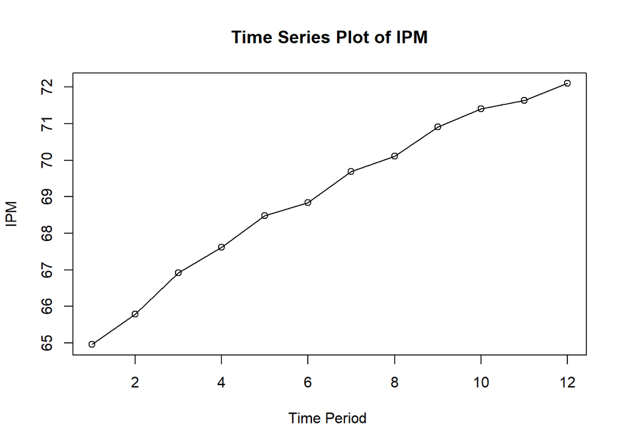

```r
#Membuat plot time series
ts.plot(data.ts, xlab="Time Period ", ylab="IPM", main= "Time Series Plot of IPM")
points(data.ts)
```

Selanjutnya akan dilakukan ramalan dan pemulusan dengan metode DMA dan DES karena terlihat pada plot di atas menunjukkan adanya *trend*.

```r
dt.sma <- SMA(data.ts, n=3)
dma <- SMA(dt.sma, n = 3)
At <- 2*dt.sma - dma
Bt <- 2/(3-1)*(dt.sma - dma)
dt.dma<- At+Bt
dt.ramal<- c(NA, dt.dma)

t = 1:5
f = c()

for (i in t) {
  f[i] = At[length(At)] + Bt[length(Bt)]*(i)
}
```

```r
dt.gab <- cbind(aktual = c(data.ts,rep(NA,5)),
                pemulusan1 = c(dt.sma,rep(NA,5)),
                pemulusan2 = c(dt.dma, rep(NA,5)),
                At = c(At, rep(NA,5)),
                Bt = c(Bt,rep(NA,5)),
                ramalan = c(dt.ramal, f[-1]))
dt.gab
```

```
##       aktual pemulusan1 pemulusan2       At        Bt  ramalan
##  [1,]  64.96         NA         NA       NA        NA       NA
##  [2,]  65.79         NA         NA       NA        NA       NA
##  [3,]  66.92   65.89000         NA       NA        NA       NA
##  [4,]  67.62   66.77667         NA       NA        NA       NA
##  [5,]  68.48   67.67333   69.46000 68.56667 0.8933333       NA
##  [6,]  68.84   68.31333   69.76444 69.03889 0.7255556 69.46000
##  [7,]  69.69   69.00333   70.35000 69.67667 0.6733333 69.76444
##  [8,]  70.11   69.54667   70.73111 70.13889 0.5922222 70.35000
##  [9,]  70.91   70.23667   71.51889 70.87778 0.6411111 70.73111
## [10,]  71.40   70.80667   72.02667 71.41667 0.6100000 71.51889
## [11,]  71.63   71.31333   72.36889 71.84111 0.5277778 72.02667
## [12,]  72.10   71.71000   72.57667 72.14333 0.4333333 72.36889
## [13,]     NA         NA         NA       NA        NA 72.57667
## [14,]     NA         NA         NA       NA        NA 73.01000
## [15,]     NA         NA         NA       NA        NA 73.44333
## [16,]     NA         NA         NA       NA        NA 73.87667
## [17,]     NA         NA         NA       NA        NA 74.31000
```

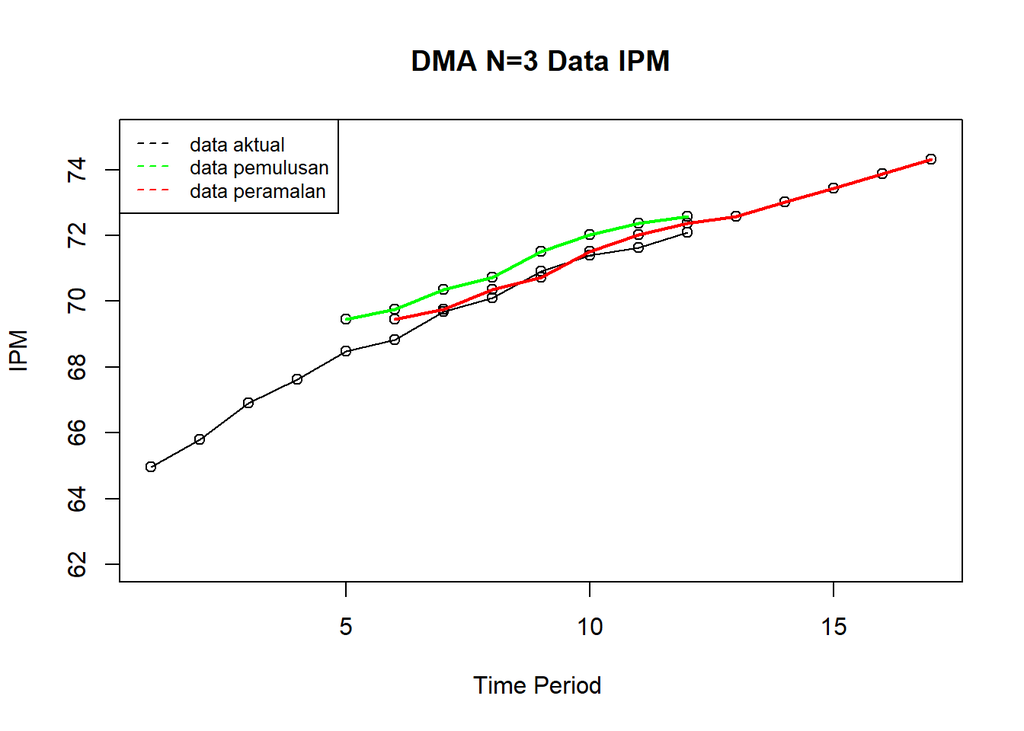

```r
#Plot time series
ts.plot(dt.gab[,1], xlab="Time Period ", ylab="IPM",
        main= "DMA N=3 Data IPM", ylim=c(62,75))
points(dt.gab[,1])
points(dt.gab[,3])
points(dt.gab[,6])
lines(dt.gab[,3],col="green",lwd=2)
lines(dt.gab[,6],col="red",lwd=2)
legend("topleft",c("data aktual","data pemulusan","data peramalan"),
       lty=8, col=c("black","green","red"), cex=0.8)
```

model sudah membentuk trend linear halus dari data aktual dengan proses smoothing bertingkat. Nilai “ramalan” muncul mulai periode ke-6 karena butuh data sebelumnya untuk menghitung dua kali pemulusan.

Selanjutnya akan dilihat keakuratan dari metode DMA

```r
#Menghitung nilai keakuratan
error.dma = data.ts-dt.ramal[1:length(data.ts)]
SSE.dma = sum(error.dma[6:length(data.ts)]^2)
MSE.dma = mean(error.dma[6:length(data.ts)]^2)
MAPE.dma = mean(abs((error.dma[6:length(data.ts)]/data.ts[6:length(data.ts)])*100))

akurasi.dma <- matrix(c(SSE.dma, MSE.dma, MAPE.dma))
row.names(akurasi.dma)<- c("SSE", "MSE", "MAPE")
colnames(akurasi.dma) <- c("Akurasi m = 3")
akurasi.dma
```

```
##      Akurasi m = 3
## SSE      0.7233235
## MSE      0.1033319
## MAPE     0.3850397
```

Selanjutnya akan digunakan metode *Double Exponential Smoothing* dengan cara sebagai berikut.

Pertama akan data akan dibagi menjadi data *training* dan data *testing*.

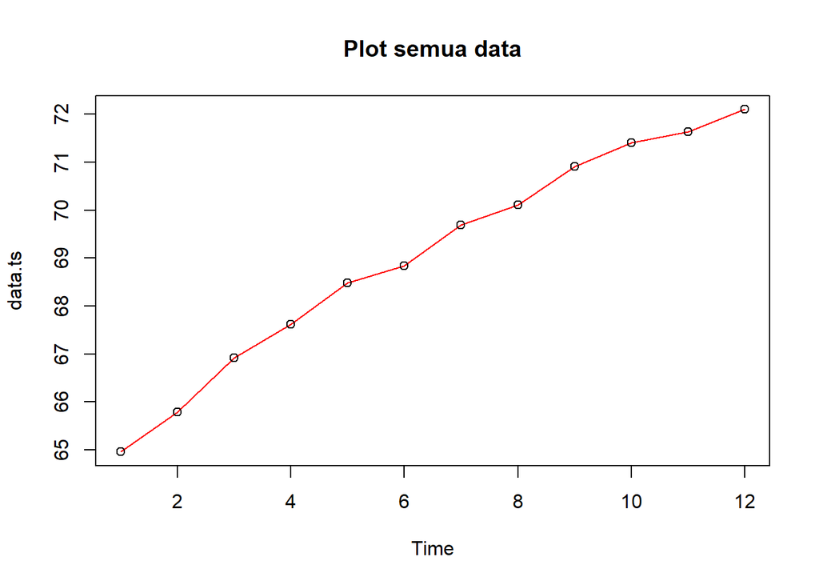

```r
#membagi training dan testing
training<-dtKepseribu[1:10,2]
testing<-dtKepseribu[11:12,2]

#data time series
training.ts<-ts(training)
testing.ts<-ts(testing,start=11)

#eksplorasi data
plot(data.ts, col="red",main="Plot semua data")
points(data.ts)
```

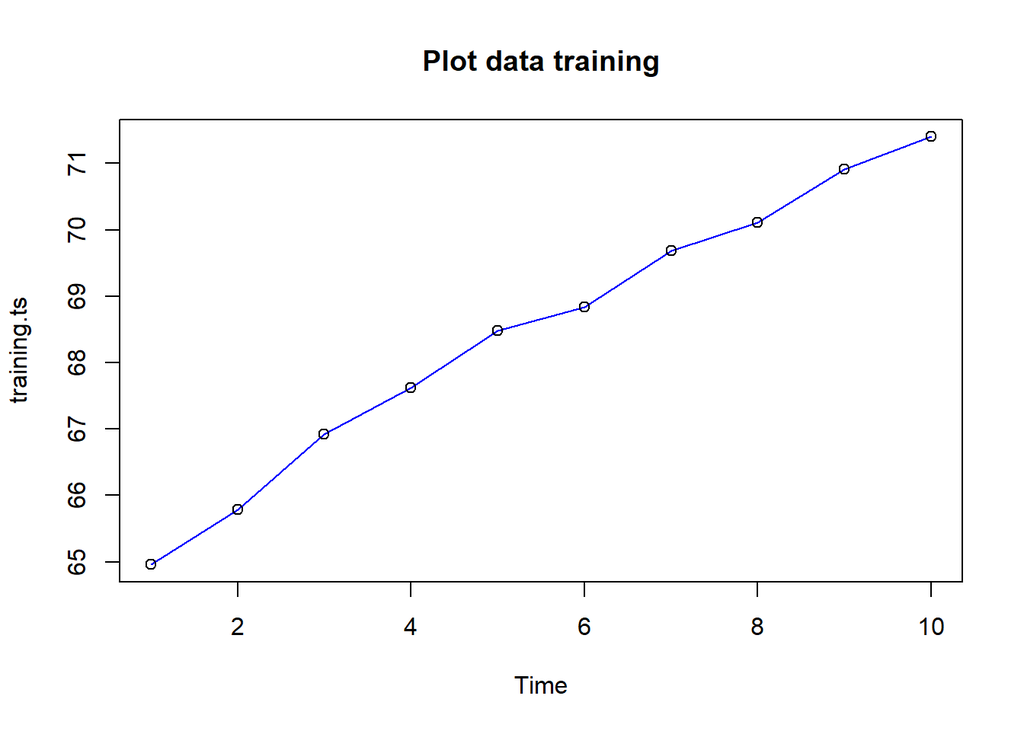

```r
plot(training.ts, col="blue",main="Plot data training")
points(training.ts)
```

Selanjutnya akan dilakukan pemulusan dengan DES, kali ini langsung dicari lambda dan gamma optimum sebagai berikut. Nilai lambda dan gamma optimum dapat dilihat pada smoothing parameters alpha untuk nilai lambda dan beta untuk nilai gamma.

```r
#Lamda dan gamma optimum
des.opt<- HoltWinters(training.ts, gamma = FALSE)
des.opt
```

```
## Holt-Winters exponential smoothing with trend and without seasonal component.
##
## Call:
## HoltWinters(x = training.ts, gamma = FALSE)
##
## Smoothing parameters:
##  alpha: 0.6611383
##  beta : 0.6374076
##  gamma: FALSE
##
## Coefficients:
##         [,1]
## a 71.4280036
## b  0.5944946
```

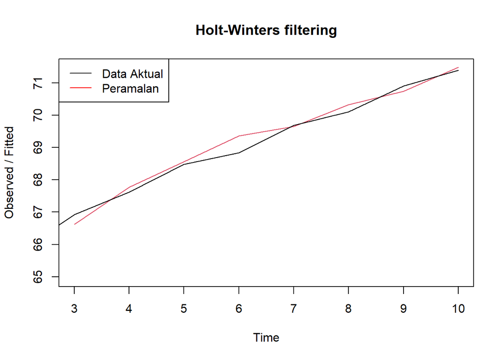

```r
plot(des.opt)
legend("topleft", c("Data Aktual", "Peramalan"), col = c("black", "red"),
       lty = c(1,1))
```

```r
#ramalan
ramalandesopt<- forecast(des.opt, h=5)
ramalandesopt
```

```
##    Point Forecast    Lo 80    Hi 80    Lo 95    Hi 95
## 11       72.02250 71.70099 72.34401 71.53079 72.51420
## 12       72.61699 72.14317 73.09081 71.89235 73.34164
## 13       73.21149 72.53450 73.88848 72.17612 74.24685
## 14       73.80598 72.88865 74.72332 72.40304 75.20893
## 15       74.40048 73.21271 75.58825 72.58394 76.21701
```

α = 0.661, β = 0.637, γ = FALSE (tidak musiman)

Alpha (α) → penghalusan level; 0.66 berarti model masih cukup responsif terhadap data baru.

Beta (β) → penghalusan tren; 0.63 berarti tren diperbarui cukup kuat tiap periode.

Gamma (γ) = FALSE → tanpa musiman.

a = 71.43, b = 0.59 → intercept & slope tren dari model.

Artinya: data punya pola tren naik stabil (b positif), dan model Holt-Winters menyesuaikan tren ini tanpa memperhitungkan pola musiman.

Selanjutnya akan dicari akurasi dari metode DES.

```r
ssedes.train<-des.opt$SSE
msedes.train<-ssedes.train/length(training.ts)
sisaandes<-ramalandesopt$residuals
head(sisaandes)
```

```
## Time Series:
## Start = 1
## End = 6
## Frequency = 1
## [1]          NA          NA  0.30000000 -0.15476585 -0.08364801 -0.52429840
```

```r
mapedes.train <- sum(abs(sisaandes[3:length(training.ts)]/training.ts[3:length(training.ts)])*100)/length(training.ts)

akurasides.opt <- matrix(c(ssedes.train,msedes.train,mapedes.train))
row.names(akurasides.opt)<- c("SSE", "MSE", "MAPE")
colnames(akurasides.opt) <- c("Akurasi lamda dan gamma optimum")
akurasides.opt
```

```
##      Akurasi lamda dan gamma optimum
## SSE                       0.47960155
## MSE                       0.04796016
## MAPE                      0.22771986
```

Model DES jauh lebih akurat dibanding DMA:

Artinya model Holt-Winters dengan parameter α dan β optimum memberikan hasil peramalan lebih stabil dan akurat.

```r
#Akurasi data testing
selisihdesopt<-ramalandesopt$mean-testing.ts
selisihdesopt
```

```
## Time Series:
## Start = 11
## End = 12
## Frequency = 1
## [1] 0.3924982 0.5169928
```

```r
SSEtestingdesopt<-sum(selisihdesopt^2)
SSEtestingdesopt<-SSEtestingdesopt/length(testing.ts)
MAPEtestingdesopt<-sum(abs(selisihdesopt/testing.ts)*100)/length(testing.ts)

akurasiDesTesting <- matrix(c(SSEtestingdesopt,SSEtestingdesopt,MAPEtestingdesopt))
row.names(akurasiDesTesting)<- c("SSE", "MSE", "MAPE")
colnames(akurasiDesTesting) <- c("Akurasi lamda dan gamma optimum")
akurasiDesTesting
```

```
##      Akurasi lamda dan gamma optimum
## SSE                        0.2106682
## MSE                        0.2106682
## MAPE                       0.6325010
```

Namun SSE masih rendah, jadi model masih cukup baik untuk short-term forecast.

Setelah didapatkan nilai akurasi untuk metode DMA dan DES, selanjutnya akan dibandingkan keakuratan antar metode keduanya.

```r
cbind(akurasi.dma, akurasides.opt)
```

```
##      Akurasi m = 3 Akurasi lamda dan gamma optimum
## SSE      0.7233235                      0.47960155
## MSE      0.1033319                      0.04796016
## MAPE     0.3850397                      0.22771986
```

DES lebih akurat di semua metrik.

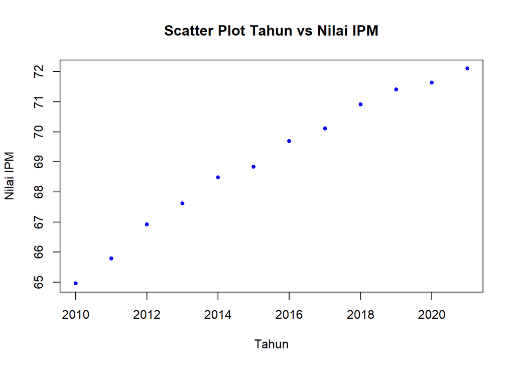

```r
#Eksplorasi Data
#Pembuatan Scatter Plot
plot(tahun,ipm, pch = 20, col = "blue",
     main = "Scatter Plot Tahun vs Nilai IPM",
     xlab = "Tahun",
     ylab = "Nilai IPM")
```

```r
#Menampilkan Nilai Korelasi
cor(tahun,ipm)
```

```
## [1] 0.9903191
```

r = 0.9903 (sangat tinggi)

Scatter plot Tahun vs IPM menunjukkan hubungan linear positif kuat — IPM naik seiring tahun.

Korelasi hampir 1 → cocok diteruskan ke model regresi linear sederhana.

# Regresi

```r
#Pembuatan Model Regresi
#model regresi
model<- lm(ipm~tahun, data = dtKepseribu)
summary(model)
```

```
##
## Call:
## lm(formula = ipm ~ tahun, data = dtKepseribu)
##
## Residuals:
##     Min      1Q  Median      3Q     Max
## -0.5265 -0.3202  0.1147  0.2120  0.4109
##
## Coefficients:
##               Estimate Std. Error t value Pr(>|t|)
## (Intercept) -1.232e+03  5.768e+01  -21.36 1.13e-09 ***
## tahun        6.456e-01  2.862e-02   22.56 6.59e-10 ***
## ---
## Signif. codes:  0 '***' 0.001 '**' 0.01 '*' 0.05 '.' 0.1 ' ' 1
##
## Residual standard error: 0.3422 on 10 degrees of freedom
## Multiple R-squared:  0.9807, Adjusted R-squared:  0.9788
## F-statistic:   509 on 1 and 10 DF,  p-value: 6.589e-10
```

Model:

IPM=−1232.0+0.6456×Tahun

Koefisien tahun signifikan (p < 0.001).

R² = 0.9807 → 98 % variasi IPM dijelaskan oleh Tahun.

F-stat = 509 (p < 0.001) → model signifikan secara keseluruhan. Kesimpulan: model linear sederhana sangat baik menjelaskan tren kenaikan IPM tiap tahun.

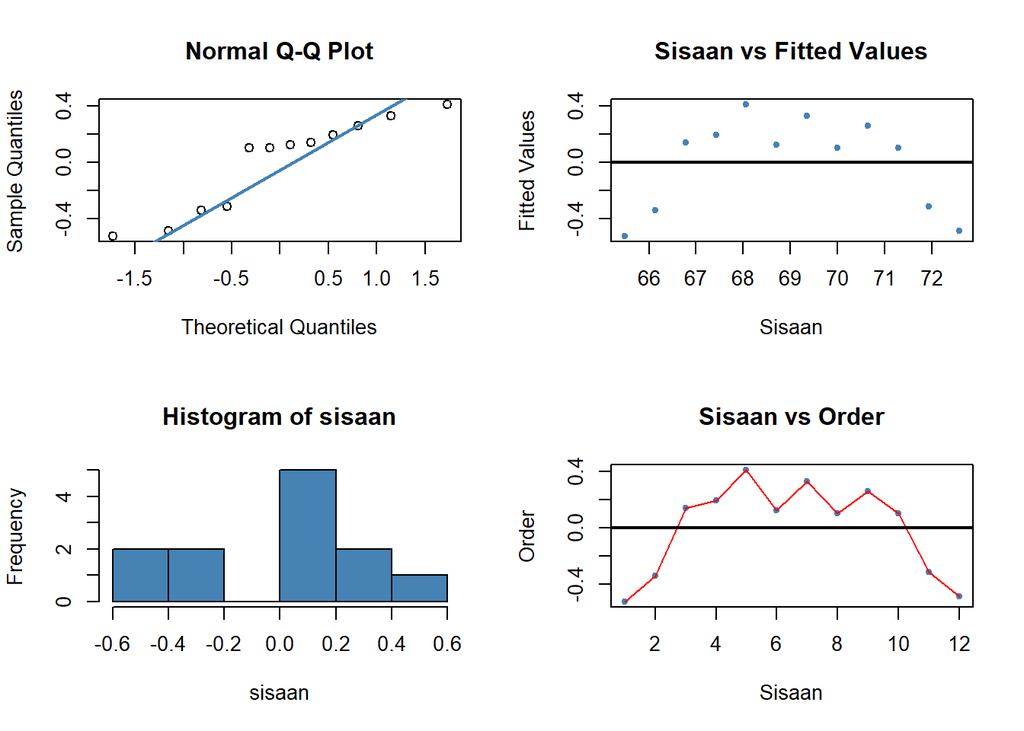

```r
#sisaan dan fitted value
sisaan<- residuals(model)
fitValue<- predict(model)

#Diagnostik dengan eksploratif
par(mfrow = c(2,2))
qqnorm(sisaan)
qqline(sisaan, col = "steelblue", lwd = 2)
plot(fitValue, sisaan, col = "steelblue", pch = 20, xlab = "Sisaan", ylab = "Fitted Values", main = "Sisaan vs Fitted Values")
abline(a = 0, b = 0, lwd = 2)
hist(sisaan, col = "steelblue")
plot(seq(1,12,1), sisaan, col = "steelblue", pch = 20, xlab = "Sisaan", ylab = "Order", main = "Sisaan vs Order")
lines(seq(1,12,1), sisaan, col = "red")
abline(a = 0, b = 0, lwd = 2)
```

Q-Q Plot → Titik mengikuti garis diagonal → residu mendekati normal.

```r
#Melihat Sisaan Menyebar Normal/Tidak
#H0: sisaan mengikuti sebaran normal
#H1: sisaan tidak mengikuti sebaran normal
shapiro.test(sisaan)
```

```
##
##  Shapiro-Wilk normality test
##
## data:  sisaan
## W = 0.87345, p-value = 0.07229
```

```r
ks.test(sisaan, "pnorm", mean=mean(sisaan), sd=sd(sisaan))
```

```
##
##  Exact one-sample Kolmogorov-Smirnov test
##
## data:  sisaan
## D = 0.29031, p-value = 0.217
## alternative hypothesis: two-sided
```

Shapiro–Wilk p = 0.072 > 0.05

Kolmogorov–Smirnov p = 0.217 > 0.05

Karena p > 0.05, tidak ada bukti menolak H₀ → residu berdistribusi normal. Asumsi normalitas terpenuhi → model regresi valid untuk inferensi.

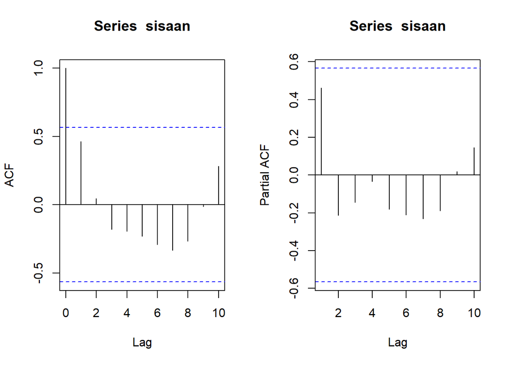

```r
#ACF dan PACF identifikasi autokorelasi
par(mfrow = c(1,2))
acf(sisaan)
pacf(sisaan)
```

PACF juga tinggi pada lag 1, kemudian turun mendekati nol.

```r
#Deteksi autokorelasi dengan uji-Durbin Watson
#H0: tidak ada autokorelasi
#H1: ada autokorelasi
dwtest(model)
```

```
##
##  Durbin-Watson test
##
## data:  model
## DW = 0.63481, p-value = 0.0003082
## alternative hypothesis: true autocorrelation is greater than 0
```

DW = 0.6348, p-value = 0.0003082

Hipotesis nol (H₀): tidak ada autokorelasi.

Hipotesis alternatif (H₁): ada autokorelasi positif.

Karena p-value < 0.05, H₀ ditolak. Nilai DW < 2 (mendekati 0) → autokorelasi positif kuat antar residual.

➡️ Kesimpulan: model regresi awal mengandung autokorelasi positif signifikan. Maka, harus dilakukan koreksi.

## Metode Cochrane-Orcutt

Penanganan metode Cochrane-Orcutt dapat dilakukan dengan bantuan packages Orcutt pada aplikasi `R` maupun secara manual. Berikut ini ditampilkan cara menggunakan bantuan `library` *packages* `Orcutt`.

```r
#Penanganan Autokorelasi Cochrane-Orcutt
modelCO<-cochrane.orcutt(model)
```

```
## Warning in cochrane.orcutt(model): Did not converge
```

```r
modelCO
```

```
## Cochrane-orcutt estimation for first order autocorrelation
##
## Call:
## lm(formula = ipm ~ tahun, data = dtKepseribu)
##
##  number of interaction: 100
##  rho 0.723228
##
## Durbin-Watson statistic
## (original):    0.63481 , p-value: 3.082e-04
## (transformed): NA , p-value: NA
##
##  coefficients:
## [1] NA
```

rho = 0.723228

Ada warning “Did not converge”

Durbin–Watson tetap sama (tidak terhitung ulang)

Makna: Proses iterasi gagal menemukan konvergensi sempurna, tapi hasil rho ≈ 0.723 tetap bisa digunakan sebagai estimasi awal tingkat autokorelasi. Artinya, sekitar 72% dari error periode sebelumnya mempengaruhi error periode saat ini → autokorelasi cukup kuat.

```r
#Rho optimum
rho<- modelCO$rho
rho
```

```
## [1] 0.7232284
```

ρ = 0.7232284

➡️ Ini adalah nilai optimum dari autokorelasi orde 1, diperoleh dari model Cochrane–Orcutt dan juga hasil konfirmasi metode Hildreth–Lu nanti. Nilai ini akan digunakan untuk melakukan transformasi manual (metode Hildreth–Lu).

Selanjutnya akan dilakukan transformasi secara manual dengan syntax berikut ini.

```r
ipm
```

```
##  [1] 64.96 65.79 66.92 67.62 68.48 68.84 69.69 70.11 70.91 71.40 71.63 72.10
```

```r
ipm[-1]
```

```
##  [1] 65.79 66.92 67.62 68.48 68.84 69.69 70.11 70.91 71.40 71.63 72.10
```

```r
#Transformasi Manual
ipm.trans<- ipm[-1]-ipm[-12]*rho
tahun.trans<- tahun[-1]-tahun[-12]*rho
modelCOmanual<- lm(ipm.trans~tahun.trans)
summary(modelCOmanual)
```

```
##
## Call:
## lm(formula = ipm.trans ~ tahun.trans)
##
## Residuals:
##      Min       1Q   Median       3Q      Max
## -0.23563 -0.15656 -0.03802  0.16950  0.26340
##
## Coefficients:
##               Estimate Std. Error t value Pr(>|t|)
## (Intercept) -244.15790   37.53751  -6.504 0.000111 ***
## tahun.trans    0.47224    0.06719   7.029 6.13e-05 ***
## ---
## Signif. codes:  0 '***' 0.001 '**' 0.01 '*' 0.05 '.' 0.1 ' ' 1
##
## Residual standard error: 0.195 on 9 degrees of freedom
## Multiple R-squared:  0.8459, Adjusted R-squared:  0.8288
## F-statistic:  49.4 on 1 and 9 DF,  p-value: 6.128e-05
```

Setelah dilakukan transformasi:

Intercept = –244.1579, slope = 0.4722

R² = 0.8459, Adjusted R² = 0.8288

F-stat = 49.4 (p-value < 0.001)

```r
#Mencari Penduga Koefisien Regresi setelah Transformasi ke Persamaan Awal
b0bintang <- modelCOmanual$coefficients[-2]
b0 <- b0bintang/(1-rho)
b1 <- modelCOmanual$coefficients[-1]
b0
```

```
## (Intercept)
##   -882.1637
```

```r
b1
```

```
## tahun.trans
##   0.4722391
```

Hasil:

β₀ (intercept sesungguhnya) = –882.1637

β₁ (kemiringan / slope) = 0.4722

➡️ Makna: Setelah dikembalikan ke bentuk asli model, setiap kenaikan 1 tahun diprediksi menaikkan IPM sebesar 0.472 poin. Intercept negatif bukan masalah karena hanya konstanta posisi garis, bukan makna ekonomis utama.

## Metode Hildreth-Lu

Penanganan kedua adalah menggunakan metode Hildreth-Lu. Metode ini akan mencari nilai SSE terkecil dan dapat dicari secara manual maupun menggunakan packages. Jika menggunakan packages, gunakan `library` *packages* `HORM`.

```r
library(HoRM)

# ambil y dan x (satu prediktor saja)
y <- dtKepseribu$ipm
x <- dtKepseribu$tahun

# grid search rho 0–0.9
r <- seq(0, 0.9, by = 0.1)
tab <- data.frame(
  rho = r,
  SSE = sapply(r, function(rr) deviance(hildreth.lu(y, x, rr)))
)

tab            # tabel rho vs SSE
```

```
##    rho       SSE
## 1  0.0 0.7779127
## 2  0.1 0.6657890
## 3  0.2 0.5703198
## 4  0.3 0.4915050
## 5  0.4 0.4293447
## 6  0.5 0.3838389
## 7  0.6 0.3549875
## 8  0.7 0.3427905
## 9  0.8 0.3472480
## 10 0.9 0.3683600
```

```r
rho_hat <- tab$rho[which.min(tab$SSE)]   # rho terbaik
fit_hl  <- hildreth.lu(y, x, rho_hat)    # model final
summary(fit_hl)
```

```
##
## Call:
## lm(formula = y ~ x)
##
## Residuals:
##      Min       1Q   Median       3Q      Max
## -0.22723 -0.15411 -0.04941  0.16864  0.26354
##
## Coefficients:
##               Estimate Std. Error t value Pr(>|t|)
## (Intercept) -274.04205   37.55694  -7.297 4.58e-05 ***
## x              0.48773    0.06203   7.863 2.54e-05 ***
## ---
## Signif. codes:  0 '***' 0.001 '**' 0.01 '*' 0.05 '.' 0.1 ' ' 1
##
## Residual standard error: 0.1952 on 9 degrees of freedom
## Multiple R-squared:  0.8729, Adjusted R-squared:  0.8588
## F-statistic: 61.83 on 1 and 9 DF,  p-value: 2.54e-05
```

```r
#Penanganan Autokorelasi Hildreth lu
# Hildreth-Lu
hildreth.lu.func<- function(r, model){
  x <- model.matrix(model)[,-1]
  y <- model.response(model.frame(model))
  n <- length(y)
  t <- 2:n
  y <- y[t]-r*y[t-1]
  x <- x[t]-r*x[t-1]

  return(lm(y~x))
}

#Pencariab rho yang meminimumkan SSE
r <- c(seq(0.1,0.9, by= 0.1))
tab <- data.frame("rho" = r, "SSE" = sapply(r, function(i){deviance(hildreth.lu.func(i, model))}))
round(tab, 4)
```

```
##   rho    SSE
## 1 0.1 0.6658
## 2 0.2 0.5703
## 3 0.3 0.4915
## 4 0.4 0.4293
## 5 0.5 0.3838
## 6 0.6 0.3550
## 7 0.7 0.3428
## 8 0.8 0.3472
## 9 0.9 0.3684
```

```r
#Rho optimal di sekitar 0.7
## Cari rho* yang meminimalkan SSE
rOpt   <- seq(0.5, 0.9, by = 0.001)

# Jika hildreth.lu.func(i, model) mengembalikan objek model dg deviance():
get_sse <- function(rho) {
  obj <- hildreth.lu.func(rho, model)
  if (!is.null(obj$deviance)) return(obj$deviance)
  if (!is.null(obj$residuals)) return(sum(residuals(obj)^2))
  return(deviance(obj))  # fallback umum
}

sse    <- sapply(rOpt, get_sse)
tabOpt <- data.frame(rho = rOpt, SSE = sse)

# titik optimal
idx_min  <- which.min(tabOpt$SSE)
rho_star <- tabOpt$rho[idx_min]
sse_star <- tabOpt$SSE[idx_min]

# lihat 6 terbaik
head(tabOpt[order(tabOpt$SSE), ], 6)
```

```
##       rho       SSE
## 224 0.723 0.3423410
## 225 0.724 0.3423414
## 223 0.722 0.3423422
## 226 0.725 0.3423435
## 222 0.721 0.3423451
## 227 0.726 0.3423473
```

```r
cat(sprintf("\nRho* = %.3f  |  SSE_min = %.5f\n", rho_star, sse_star))
```

```
##
## Rho* = 0.723  |  SSE_min = 0.34234
```

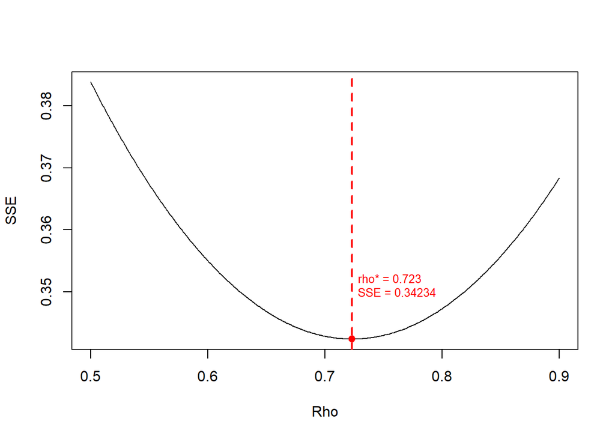

```r
## ---- Plot SSE vs rho + anotasi ---------------------------------------
par(mfrow = c(1,1))
plot(tabOpt$rho, tabOpt$SSE, type = "l", xlab = "Rho", ylab = "SSE")
abline(v = rho_star, lty = 2, col = "red", lwd = 2)
points(rho_star, sse_star, pch = 19, col = "red")

# label otomatis sedikit ke kanan/atas biar tidak menimpa titik
text(x = rho_star + 0.005,
     y = sse_star * 1.02,
     labels = sprintf("rho* = %.3f\nSSE = %.5f", rho_star, sse_star),
     cex = 0.8, col = "red", adj = c(0, 0))
```

```r
## Model terbaik berdasarkan rho optimum
# Ambil rho optimum dari tabOpt
rho_star <- tabOpt$rho[which.min(tabOpt$SSE)]

# Estimasi model dengan rho optimum
modelHL <- hildreth.lu.func(rho_star, model)

# Ringkasan model
summary(modelHL)
```

```
##
## Call:
## lm(formula = y ~ x)
##
## Residuals:
##      Min       1Q   Median       3Q      Max
## -0.23554 -0.15653 -0.03813  0.16949  0.26340
##
## Coefficients:
##               Estimate Std. Error t value Pr(>|t|)
## (Intercept) -244.45170   37.53745  -6.512  0.00011 ***
## x              0.47240    0.06713   7.037 6.07e-05 ***
## ---
## Signif. codes:  0 '***' 0.001 '**' 0.01 '*' 0.05 '.' 0.1 ' ' 1
##
## Residual standard error: 0.195 on 9 degrees of freedom
## Multiple R-squared:  0.8462, Adjusted R-squared:  0.8291
## F-statistic: 49.52 on 1 and 9 DF,  p-value: 6.073e-05
```

```r
## Transformasi balik ke bentuk aslinya
intercept <- coef(modelHL)[1]
slope     <- coef(modelHL)[2]

cat(
  "Persamaan model (transformasi balik):\n",
  "y = ", round(intercept / (1 - rho_star), 4),
  " + ", round(slope, 4), "x",
  "\n\n",
  "Dengan rho optimum =", round(rho_star, 3),
  " dan SSE minimum =", round(min(tabOpt$SSE), 5),
  sep = ""
)
```

```
## Persamaan model (transformasi balik):
## y = -882.4971 + 0.4724x
##
## Dengan rho optimum =0.723 dan SSE minimum =0.34234
```

```r
#Deteksi autokorelasi
dwtest(modelHL)
```

```
##
##  Durbin-Watson test
##
## data:  modelHL
## DW = 2.9726, p-value = 0.9232
## alternative hypothesis: true autocorrelation is greater than 0
```

DW = 2.9726, p-value = 0.9232 Interpretasi:

Hipotesis nol (H₀): tidak ada autokorelasi.

Hipotesis alternatif (H₁): ada autokorelasi positif.

Nilai DW ≈ 3 dan p-value > 0.05, artinya tidak ada autokorelasi positif, bahkan sedikit mengarah ke autokorelasi negatif kecil tapi tidak signifikan. Dengan kata lain, model setelah koreksi sudah bebas autokorelasi.

Makna penting: Transformasi Hildreth–Lu berhasil mengatasi autokorelasi positif yang awalnya sangat kuat (DW awal 0.63).

```r
#Perbandingan
sseModelawal <- anova(model)$`Sum Sq`[-1]
sseModelCO <- anova(modelCOmanual)$`Sum Sq`[-1]
sseModelHL <- anova(modelHL)$`Sum Sq`[-1]
mseModelawal <- sseModelawal/length(ipm)
mseModelCO <- sseModelCO/length(ipm)
mseModelHL <- sseModelHL/length(ipm)
akurasi <- matrix(c(sseModelawal,sseModelCO,sseModelHL,
                    mseModelawal,mseModelCO,mseModelHL),nrow=2,ncol=3,byrow = T)
colnames(akurasi) <- c("Model Awal", "Model Cochrane-Orcutt", "Model Hildreth-Lu")
row.names(akurasi) <- c("SSE","MSE")
akurasi
```

```
##     Model Awal Model Cochrane-Orcutt Model Hildreth-Lu
## SSE 1.17109336            0.34234093        0.34234097
## MSE 0.09759111            0.02852841        0.02852841
```

Makna hasil:

Baik Cochrane–Orcutt maupun Hildreth–Lu sama-sama menurunkan SSE sebesar ~70% dibanding model awal.

Karena Cochrane–Orcutt gagal konvergen (lihat hasil sebelumnya), Hildreth–Lu menjadi solusi yang lebih stabil dan bisa dijalankan manual.